# CCIWR code

Felix Zaussinger and Johann Schuur

30.04.2020

## Approach

1. check correlation GRUN with GRDC at Mosul -> correlation of 0,62, using station data as truth
2. convert units GRUN data to volume, aprrox ~ 50x50 km. Note pixels have different areas on globe.
3. run regression with altimetry as explanatory variable
4. negative correlation between discarge and water level at Mosul: p = -0.66
5. use altimetry data at mosul to predict GRUN discharge from 2014 onwards at location of Ilisu by running another regression.
6. compare to “seasonal” fluctuations before Ilisu filling -> compare to flow-data from “2020 Hydrological Impact of Ilisu Dam on Mosul Dam; the River Tigris”, and “2006 Ilisu Report Williams”
7. Suggest filling and release scenarios, e.g. take everything above mean.

### Assumptions

1. Tigris largest contribuatory in the “pixel”.
2. We use altimetry (until April 15th) as a proxy to prolong GRUN data (until 2014) by running a regression.

### Questions for Tobias

1. We see an increase in discharge at mosul after the filling (according to 3rd party source) had started. We would have expected more of a continuous decrease.
2. The last plot shows the data that we now intend to use for the filling analysis. It is based on the regression with alttimetry data. We know that there are many flaws and we had to make a lot of assumptions, but it is the best data we have. Johann asked the Iraqui water ministry for data but they didn’t respond. Do you think that it is reasonable? We cannot really judge if it makes sense that discharge is way higher at Ilisu than at Mosul. It probably depends on whether evaporation or further inflow from tributaries downstream of Ilisu dominate.
3. Do you think that we can now use this approach for answering our question about the filling and operation schedule of Ilisu dam, keeping in mind the limitations and error ranges of the data?

## Data

Read GRDC discharge time series for Besiri, Mosul, Bagdad. Discharge is in m^3/s.

```r
station_data_besiri <- read.delim(file = "./data/GRDC_discharge/6695600_Q_Month.txt",
                                 header = TRUE,
                                 col.names = c("date", "time", "discharge_obs", "discharge_calc", "percent_valid"),
                                 colClasses = c("Date", "NULL", "double", "double", "double"),
                                 sep=";",
                                 comment.char = '#',
                                 na.strings = c("",".","NA", "   -999.000"),
                                 fill = TRUE)

station_data_mosul <- read.delim(file = "./data/GRDC_discharge/2595600_Q_Month.txt",
                                 header = TRUE,
                                 col.names = c("date", "time", "discharge_obs", "discharge_calc", "percent_valid"),
                                 colClasses = c("Date", "NULL", "double", "double", "double"),
                                 sep=";",
                                 comment.char = '#', # explicit way would be: skip = 38,
                                 na.strings = c("",".","NA", "   -999.000"),
                                 fill = TRUE)

station_data_bagdad <- read.delim(file = "./data/GRDC_discharge/2595700_Q_Month.txt",
                                 header = TRUE,
                                 col.names = c("date", "time", "discharge_obs", "discharge_calc", "percent_valid"),
                                 colClasses = c("Date", "NULL", "double", "double", "double"),
                                 sep=";",
                                 comment.char = '#',
                                 na.strings = c("",".","NA", "   -999.000"),
                                 fill = TRUE)

# define nan values
station_data_besiri[station_data_besiri == -999] <- NA
station_data_mosul[station_data_mosul == -999] <- NA
station_data_bagdad[station_data_bagdad == -999] <- NA
```

Read GRUN data

```r
# open netCDF file
grun <- nc_open("./data/GRUN_discharge_cropped_small_tigris.nc")

lat <- ncvar_get(grun, "X")
lon <- ncvar_get(grun, "Y")
time <- ncvar_get(grun, "time")
tunits <- ncatt_get(grun,"time","units")
runoff <- ncvar_get(grun, "Runoff") # mm/day

# convert time -- split the time units string into fields
from <- strsplit(tunits$value, " ")
tstamps <- as.Date(time, origin=unlist(from)[3])

# mosul time series location
# Mosul: lat = 36.32, lon = 43.15
# Bagdad: lat = 33.30, lon = 44.38

read_grun <- function(lat_point, lon_point) {
  lat_idx <- which.min(abs(lat - lat_point)) # X
  lon_idx <- which.min(abs(lon - lon_point)) # Y
  grun_data <- (runoff[lat_idx, lon_idx,])
  df_grun <- data.frame(date = tstamps, runoff = grun_data)
  return(df_grun)
}

# combine to data frame
df_grun <- read_grun(36.32, 43.15)

# grun_ilisu
grun_ilisu <- read_grun(37.530112, 41.851024)
```

Read Dahiti altimetry data

```r
# read csv file
dahiti <- read.table("./data/Dahiti_dgfi_tum_altimetry/dahiti.dgfi.tum.de.txt")

# open netCDF file
dahiti_nc <- nc_open("./data/Dahiti_dgfi_tum_altimetry/118_water_level_altimetry.nc")
```

Summary

```r
besiri <- as.data.frame(tidy(summary(station_data_besiri$discharge_obs)))
mosul <- as.data.frame(tidy(summary(station_data_mosul$discharge_obs))[,1:6])
bagdad <- as.data.frame(tidy(summary(station_data_bagdad$discharge_obs))[,1:6])

row.names(besiri) <- "Besiri"
row.names(mosul) <- "Mosul"
row.names(bagdad) <- "Bagdad"

rbind(besiri, mosul, bagdad)
```

|  | minimum | q1 | median | mean | q3 | maximum |
| --- | --- | --- | --- | --- | --- | --- |
| Besiri | 0 | 4.0 | 18 | 42.26 | 60.5 | 276 |
| Mosul | 124 | 275.5 | 521 | 872.58 | 1251.0 | 3228 |
| Bagdad | 158 | 430.0 | 815 | 1192.17 | 1680.0 | 6110 |

Time series plot

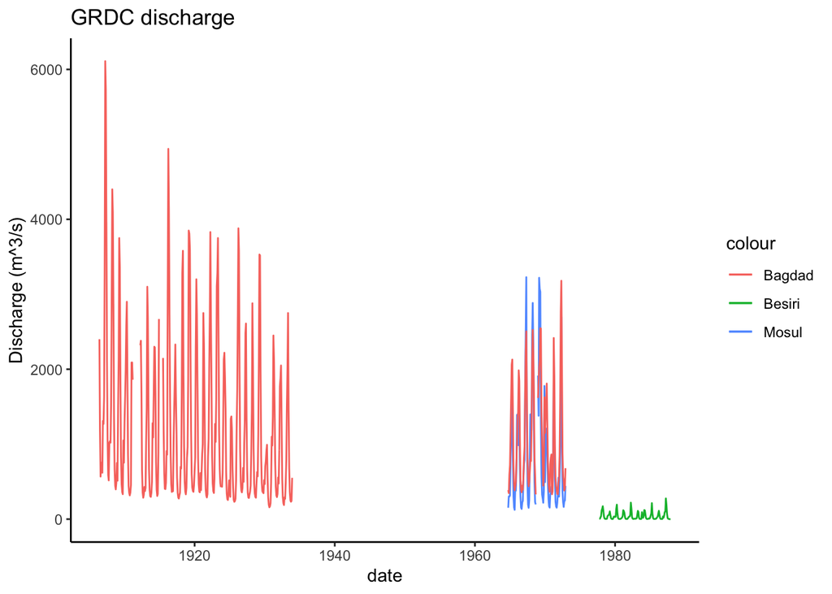

```r
# Discharge plot
ggplot() +
  geom_line(aes(x=date, y=discharge_obs, color="Besiri"), data = station_data_besiri) +
  geom_line(aes(x=date, y=discharge_obs, color="Mosul"), data = station_data_mosul) +
  geom_line(aes(x=date, y=discharge_obs, color="Bagdad"), data = station_data_bagdad) +
  labs(title="GRDC discharge", y="Discharge (m^3/s)")
```

normalise with z-score

```r
df_grun$runoff_norm <- (df_grun$runoff - mean(df_grun$runoff, na.rm = TRUE)) / sd(df_grun$runoff, na.rm = TRUE)

station_data_besiri$discharge_obs_norm <- (station_data_besiri$discharge_obs - mean(station_data_besiri$discharge_obs, na.rm = TRUE)) / sd(station_data_besiri$discharge_obs, na.rm = TRUE)

station_data_mosul$discharge_obs_norm <- (station_data_mosul$discharge_obs - mean(station_data_mosul$discharge_obs, na.rm = TRUE)) / sd(station_data_mosul$discharge_obs, na.rm = TRUE)

station_data_bagdad$discharge_obs_norm <- (station_data_bagdad$discharge_obs - mean(station_data_bagdad$discharge_obs, na.rm = TRUE)) / sd(station_data_bagdad$discharge_obs, na.rm = TRUE)
```

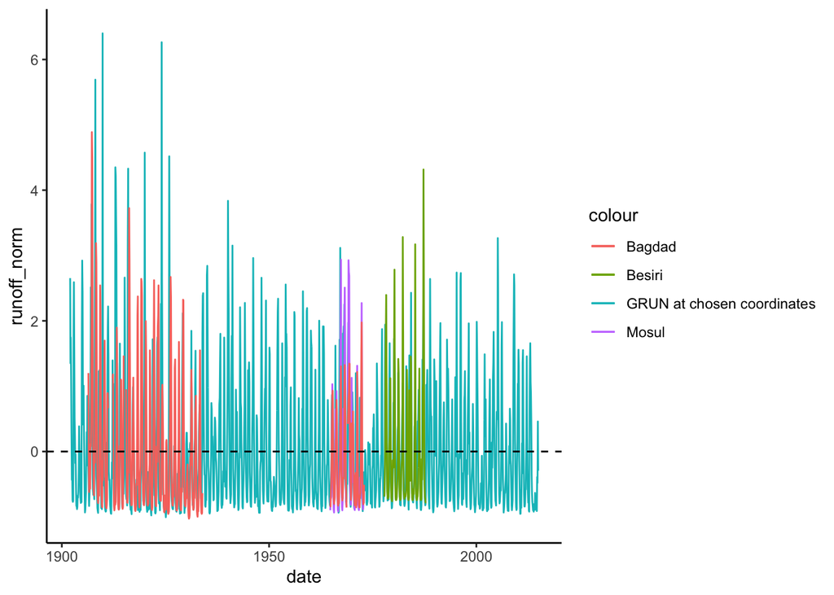

```r
ggplot() +
  geom_line(aes(x=date, y=runoff_norm, color="GRUN at chosen coordinates"), data = df_grun) +
  geom_line(aes(x=date, y=discharge_obs_norm, color="Besiri"), data = station_data_besiri) +
  geom_line(aes(x=date, y=discharge_obs_norm, color="Mosul"), data = station_data_mosul) +
  geom_line(aes(x=date, y=discharge_obs_norm, color="Bagdad"), data = station_data_bagdad) +
  geom_hline(yintercept = 0, linetype = "dashed")
```

TUM Dahiti water level data Mosul dam in m

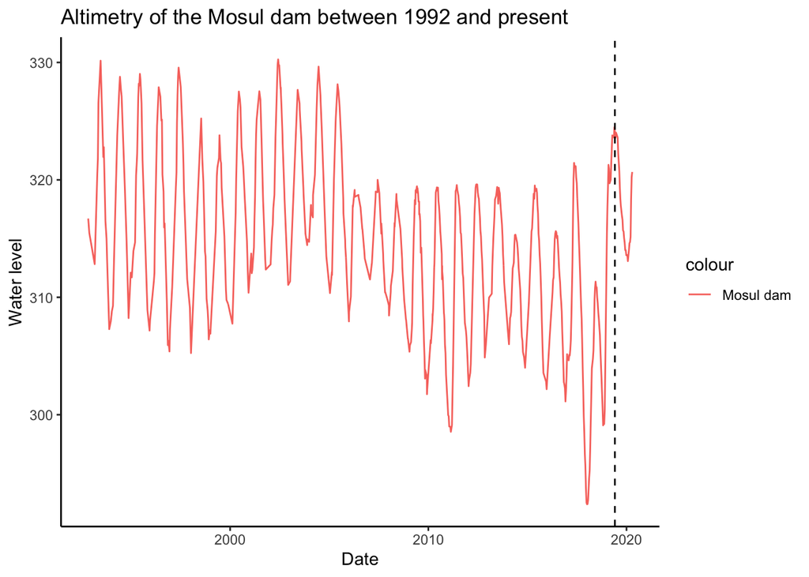

```r
# Altimetry time series plot
dahiti$V1 <- as.Date(dahiti$V1, '%Y-%m-%d')

ggplot() +
  geom_line(aes(x = V1, y = V2, colour = "Mosul dam"), data = dahiti) +
  # add minimal water level required in Mosul dam
  #geom_hline(yintercept = 300, linetype = "dashed") +
  geom_vline(xintercept = as.numeric(as.Date("2019-06-01")), linetype = "dashed") +
  labs(x = "Date", y = "Water level", title = "Altimetry of the Mosul dam between 1992 and present")
```

Violinplot

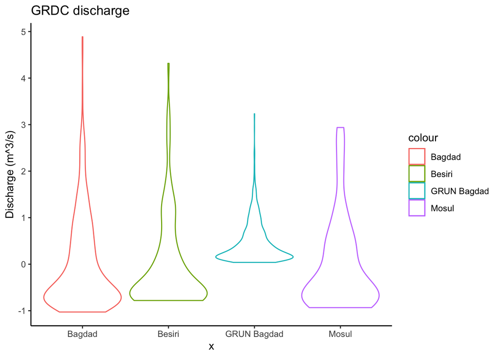

```r
ggplot() +
  geom_violin(aes(x='Besiri', y=discharge_obs_norm, color="Besiri"), data = station_data_besiri) +
  geom_violin(aes(x='Mosul', y=discharge_obs_norm, color="Mosul"), data = station_data_mosul) +
  geom_violin(aes(x='Bagdad', y=discharge_obs_norm, color="Bagdad"), data = station_data_bagdad) +
  geom_violin(aes(x='GRUN Bagdad', y=runoff, color="GRUN Bagdad"), data = df_grun) +
  labs(title="GRDC discharge", y="Discharge (m^3/s)")
```

```r
  #geom_line(aes(x=date, y=discharge_obs, color="Besiri"), data = station_data_besiri) +
  #geom_line(aes(x=date, y=discharge_obs, color="Mosul"), data = station_data_mosul) +
  #geom_line(aes(x=date, y=discharge_obs, color="Bagdad"), data = station_data_bagdad) +
```

```r
df_merged <- merge(df_grun, station_data_mosul, by="date")

tidy(cor.test(df_merged$runoff_norm, df_merged$discharge_obs_norm))
```

| estimate | statistic | p.value | parameter | conf.low | conf.high | method | alternative |
| --- | --- | --- | --- | --- | --- | --- | --- |
| 0.6255 | 7.773 | 9.536e-12 | 94 | 0.486 | 0.734 | Pearson's product-moment correlation | two.sided |

corr altimetry

```r
altimetry_mosul <- data.frame(date=dahiti$V1, water_level = dahiti$V2)

df_merged2 <- merge(df_grun, altimetry_mosul, by="date")

tidy(cor.test(df_merged2$runoff, df_merged2$water_level))
```

| estimate | statistic | p.value | parameter | conf.low | conf.high | method | alternative |
| --- | --- | --- | --- | --- | --- | --- | --- |
| -0.6638 | -3.438 | 0.003663 | 15 | -0.8676 | -0.269 | Pearson's product-moment correlation | two.sided |

Based on an article is likely that the filling of Ilisu started June 10th. Source: https://www.reuters.com/article/us-turkey-dam-erdogan-idUSKCN1QO1V5

```r
ols <- lm(runoff ~ water_level, df_merged2)
tidy(summary(ols))
```

| term | estimate | std.error | statistic | p.value |
| --- | --- | --- | --- | --- |
| (Intercept) | 6.60393 | 1.834137 | 3.601 | 0.002623 |
| water_level | -0.02006 | 0.005835 | -3.438 | 0.003663 |

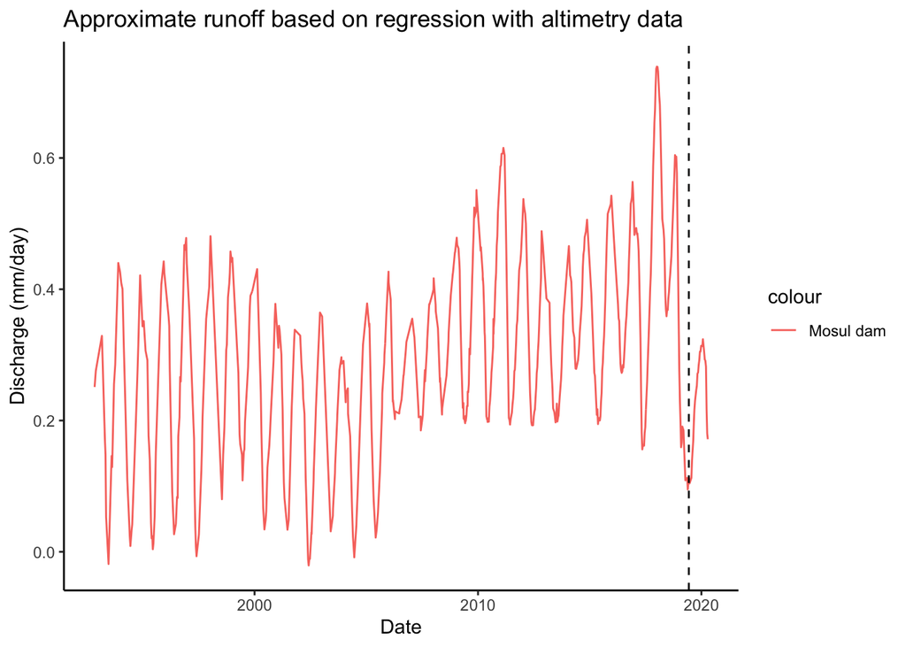

```r
beta0 = as.numeric(coef(ols)[1])
beta1 = as.numeric(coef(ols)[2])

altimetry_mosul$discharge_prediction <- beta0 + beta1 * altimetry_mosul$water_level

ggplot() +
  geom_line(aes(x = date, y = discharge_prediction, colour = "Mosul dam"), data = altimetry_mosul) +
  # add minimal water level required in Mosul dam
  #geom_hline(yintercept = 300, linetype = "dashed") +
  geom_vline(xintercept = as.numeric(as.Date("2019-06-10")), linetype = "dashed") +
  labs(x = "Date", y = "Discharge (mm/day)", title = "Approximate runoff based on regression with altimetry data")
```

repeat for ilisu

```r
df_merged_ilisu <- merge(grun_ilisu, altimetry_mosul, by="date")
tidy(cor.test(df_merged_ilisu$runoff, df_merged_ilisu$water_level))
```

| estimate | statistic | p.value | parameter | conf.low | conf.high | method | alternative |
| --- | --- | --- | --- | --- | --- | --- | --- |
| -0.653 | -3.339 | 0.004481 | 15 | -0.8628 | -0.2512 | Pearson's product-moment correlation | two.sided |

```r
ols_ilisu <- lm(runoff ~ water_level, df_merged_ilisu)
tidy(summary(ols_ilisu))
```

| term | estimate | std.error | statistic | p.value |
| --- | --- | --- | --- | --- |
| (Intercept) | 13.65579 | 3.91055 | 3.492 | 0.003277 |
| water_level | -0.04155 | 0.01244 | -3.339 | 0.004481 |

```r
beta0 = as.numeric(coef(ols_ilisu)[1])
beta1 = as.numeric(coef(ols_ilisu)[2])

altimetry_mosul$discharge_prediction_ilisu <- beta0 + beta1 * altimetry_mosul$water_level
```

plot resulting ts for ilisu and mosul

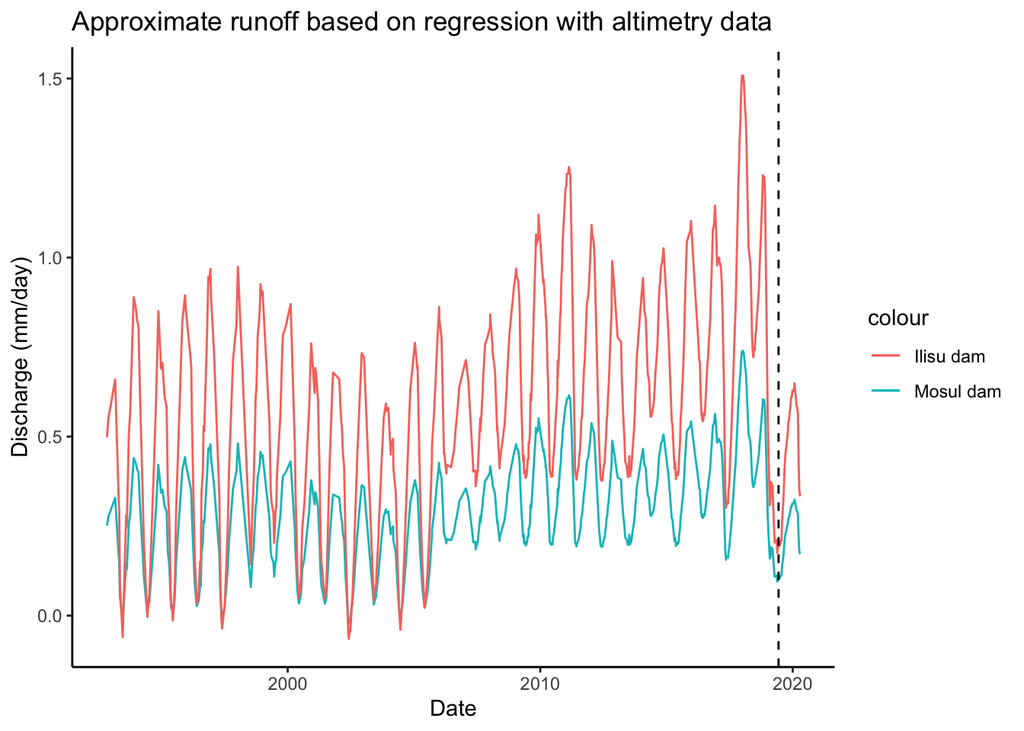

```r
ggplot() +
  geom_line(aes(x = date, y = discharge_prediction, colour = "Mosul dam"), data = altimetry_mosul) +
  geom_line(aes(x = date, y = discharge_prediction_ilisu, colour = "Ilisu dam"), data = altimetry_mosul) +
  # add minimal water level required in Mosul dam
  #geom_hline(yintercept = 300, linetype = "dashed") +
  geom_vline(xintercept = as.numeric(as.Date("2019-06-10")), linetype = "dashed") +
  labs(x = "Date", y = "Discharge (mm/day)", title = "Approximate runoff based on regression with altimetry data")
```